# 1. Problem statement

1. To what extent can structured Airbnb data support decision-making frameworks for tourism planning?
2. What analytical frameworks are most suitable for leveraging Airbnb Big Data in strategic tourism planning?
3. How can structured data from Airbnb listings inform the adaptation of prescriptive models for demand forecasting and host behavior analysis in tourism destinations?
4. Can forecasting models built on Airbnb data from one city be applied effectively to other cities for strategic tourism planning?

# 2. Data Collection

```python
import pandas as pd
import numpy as np
import matplotlib.pyplot as plt
import seaborn as sns

from datetime import datetime
```

```python
pd.set_option("display.max_columns", None)
```

```python
df_1 = pd.read_csv("/Users/brigitte/Desktop/Tesis Maestria/Thesis pipeline OG/LONDON/listings.csv", encoding="utf-8")
```

```python
df_1.info()
```

```
<class 'pandas.core.frame.DataFrame'>
RangeIndex: 96651 entries, 0 to 96650
Data columns (total 18 columns):
 #   Column                          Non-Null Count  Dtype
---  ------                          --------------  -----
 0   id                              96651 non-null  int64
 1   name                            96651 non-null  object
 2   host_id                         96651 non-null  int64
 3   host_name                       96611 non-null  object
 4   neighbourhood_group             0 non-null      float64
 5   neighbourhood                   96651 non-null  object
 6   latitude                        96651 non-null  float64
 7   longitude                       96651 non-null  float64
 8   room_type                       96651 non-null  object
 9   price                           62684 non-null  float64
 10  minimum_nights                  96651 non-null  int64
 11  number_of_reviews               96651 non-null  int64
 12  last_review                     71487 non-null  object
 13  reviews_per_month               71487 non-null  float64
 14  calculated_host_listings_count  96651 non-null  int64
 15  availability_365                96651 non-null  int64
 16  number_of_reviews_ltm           96651 non-null  int64
 17  license                         0 non-null      float64
dtypes: float64(6), int64(7), object(5)
memory usage: 13.3+ MB
```

```python
df_2 = pd.read_csv("/Users/brigitte/Desktop/Tesis Maestria/Thesis pipeline OG/LONDON/listings 2.csv", encoding="utf-8")
```

```python
df_2.info()
```

```
<class 'pandas.core.frame.DataFrame'>
RangeIndex: 96651 entries, 0 to 96650
Data columns (total 79 columns):
 #   Column                                        Non-Null Count  Dtype
---  ------                                        --------------  -----
 0   id                                            96651 non-null  int64
 1   listing_url                                   96651 non-null  object
 2   scrape_id                                     96651 non-null  int64
 3   last_scraped                                  96651 non-null  object
 4   source                                        96651 non-null  object
 5   name                                          96651 non-null  object
 6   description                                   93806 non-null  object
 7   neighborhood_overview                         41983 non-null  object
 8   picture_url                                   96642 non-null  object
 9   host_id                                       96651 non-null  int64
```

[output cut: 71 more lines]

```python
df = df_1.merge(df_2, on="id", how="inner")
```

```python
df.head()
```

|  | id | name_x | host_id_x | host_name_x | neighbourhood_group | neighbourhood_x | latitude_x | longitude_x | room_type_x | price_x | minimum_nights_x | number_of_reviews_x | last_review_x | reviews_per_month_x | calculated_host_listings_count_x | availability_365_x | number_of_reviews_ltm_x | license_x | listing_url | scrape_id | last_scraped | source | name_y | description | neighborhood_overview | picture_url | host_id_y | host_url | host_name_y | … |
| --- | --- | --- | --- | --- | --- | --- | --- | --- | --- | --- | --- | --- | --- | --- | --- | --- | --- | --- | --- | --- | --- | --- | --- | --- | --- | --- | --- | --- | --- | --- |
| 0 | 264776 | Huge Four Bedroom Apartment | 1389063 | Sue | NaN | Lewisham | 51.44306 | -0.01948 | Entire home/apt | 297.0 | 3 | 68 | 2025-05-28 | 0.51 | 11 | 293 | 12 | NaN | https://www.airbnb.com/rooms/264776 | 20250610032232 | 2025-06-11 | city scrape | Huge Four Bedroom Apartment | An extremely large and sunny four bedroom grou... | Catford is a well established London suburb. T... | https://a0.muscache.com/pictures/hosting/Hosti... | 1389063 | https://www.airbnb.com/users/show/1389063 | Sue | … |
| 1 | 264777 | One Bedroom Apartment | 1389063 | Sue | NaN | Lewisham | 51.44284 | -0.01997 | Entire home/apt | 98.0 | 3 | 24 | 2024-12-11 | 0.22 | 11 | 318 | 4 | NaN | https://www.airbnb.com/rooms/264777 | 20250610032232 | 2025-06-11 | city scrape | One Bedroom Apartment | Recently refurbished sunny one bedroom first f... | NaN | https://a0.muscache.com/pictures/hosting/Hosti... | 1389063 | https://www.airbnb.com/users/show/1389063 | Sue | … |
| 2 | 264778 | Two Bedroom Newly Refurbished Apartment | 1389063 | Sue | NaN | Lewisham | 51.44359 | -0.02275 | Entire home/apt | 148.0 | 3 | 58 | 2025-05-01 | 0.43 | 11 | 302 | 6 | NaN | https://www.airbnb.com/rooms/264778 | 20250610032232 | 2025-06-11 | city scrape | Two Bedroom Newly Refurbished Apartment | A large and sunny two bedroom second floor apa... | Catford is a well established London suburb. T... | https://a0.muscache.com/pictures/50662093/af12... | 1389063 | https://www.airbnb.com/users/show/1389063 | Sue | … |
| 3 | 264779 | Refurbished Two Bedroom Apartment | 1389063 | Sue | NaN | Lewisham | 51.44355 | -0.02309 | Entire home/apt | 144.0 | 3 | 36 | 2025-04-10 | 0.30 | 11 | 328 | 7 | NaN | https://www.airbnb.com/rooms/264779 | 20250610032232 | 2025-06-11 | city scrape | Refurbished Two Bedroom Apartment | A large and sunny two bedroom second floor apa... | Catford is a well established London suburb. T... | https://a0.muscache.com/pictures/50660860/e440... | 1389063 | https://www.airbnb.com/users/show/1389063 | Sue | … |
| 4 | 264780 | Spacious refurbished 2 bedroom apt with balcony | 1389063 | Sue | NaN | Lewisham | 51.44333 | -0.02307 | Entire home/apt | 157.0 | 3 | 54 | 2024-12-29 | 0.35 | 11 | 255 | 4 | NaN | https://www.airbnb.com/rooms/264780 | 20250610032232 | 2025-06-11 | city scrape | Spacious refurbished 2 bedroom apt with balcony | Completely refurbished 2 bedroom apt to sleep ... | NaN | https://a0.muscache.com/pictures/airflow/Hosti... | 1389063 | https://www.airbnb.com/users/show/1389063 | Sue | … |

# 3. Data Cleaning

```python
#Dropping duplicate columns

cols = df.columns
cols_x = [c for c in cols if c.endswith("_x")]
cols_y = [c for c in cols if c.endswith("_y")]

df = df.drop(columns= cols_x)

rename_dict = {col: col.replace("_y", "") for col in cols_y}
df = df.rename(columns=rename_dict)
```

```python
#Dropping columns that all values are null

df_1 = df.dropna(axis=1, how="all")
df_1.info()
```

```
<class 'pandas.core.frame.DataFrame'>
Int64Index: 96651 entries, 0 to 96650
Data columns (total 76 columns):
 #   Column                                        Non-Null Count  Dtype
---  ------                                        --------------  -----
 0   id                                            96651 non-null  int64
 1   listing_url                                   96651 non-null  object
 2   scrape_id                                     96651 non-null  int64
 3   last_scraped                                  96651 non-null  object
 4   source                                        96651 non-null  object
 5   name                                          96651 non-null  object
 6   description                                   93806 non-null  object
 7   neighborhood_overview                         41983 non-null  object
 8   picture_url                                   96642 non-null  object
 9   host_id                                       96651 non-null  int64
```

[output cut: 68 more lines]

```python
df_1.head()
```

|  | id | listing_url | scrape_id | last_scraped | source | name | description | neighborhood_overview | picture_url | host_id | host_url | host_name | host_since | host_location | host_about | host_response_time | host_response_rate | host_acceptance_rate | host_is_superhost | host_thumbnail_url | host_picture_url | host_neighbourhood | host_listings_count | host_total_listings_count | host_verifications | host_has_profile_pic | host_identity_verified | neighbourhood | neighbourhood_cleansed | … |
| --- | --- | --- | --- | --- | --- | --- | --- | --- | --- | --- | --- | --- | --- | --- | --- | --- | --- | --- | --- | --- | --- | --- | --- | --- | --- | --- | --- | --- | --- | --- |
| 0 | 264776 | https://www.airbnb.com/rooms/264776 | 20250610032232 | 2025-06-11 | city scrape | Huge Four Bedroom Apartment | An extremely large and sunny four bedroom grou... | Catford is a well established London suburb. T... | https://a0.muscache.com/pictures/hosting/Hosti... | 1389063 | https://www.airbnb.com/users/show/1389063 | Sue | 2011-11-09 | United Kingdom | I own the Glenthurston Apartments and have don... | within an hour | 86% | 100% | f | https://a0.muscache.com/im/pictures/user/a0985... | https://a0.muscache.com/im/pictures/user/a0985... | Bellingham | 11.0 | 12.0 | ['email', 'phone'] | t | t | Neighborhood highlights | Lewisham | … |
| 1 | 264777 | https://www.airbnb.com/rooms/264777 | 20250610032232 | 2025-06-11 | city scrape | One Bedroom Apartment | Recently refurbished sunny one bedroom first f... | NaN | https://a0.muscache.com/pictures/hosting/Hosti... | 1389063 | https://www.airbnb.com/users/show/1389063 | Sue | 2011-11-09 | United Kingdom | I own the Glenthurston Apartments and have don... | within an hour | 86% | 100% | f | https://a0.muscache.com/im/pictures/user/a0985... | https://a0.muscache.com/im/pictures/user/a0985... | Bellingham | 11.0 | 12.0 | ['email', 'phone'] | t | t | NaN | Lewisham | … |
| 2 | 264778 | https://www.airbnb.com/rooms/264778 | 20250610032232 | 2025-06-11 | city scrape | Two Bedroom Newly Refurbished Apartment | A large and sunny two bedroom second floor apa... | Catford is a well established London suburb. T... | https://a0.muscache.com/pictures/50662093/af12... | 1389063 | https://www.airbnb.com/users/show/1389063 | Sue | 2011-11-09 | United Kingdom | I own the Glenthurston Apartments and have don... | within an hour | 86% | 100% | f | https://a0.muscache.com/im/pictures/user/a0985... | https://a0.muscache.com/im/pictures/user/a0985... | Bellingham | 11.0 | 12.0 | ['email', 'phone'] | t | t | Neighborhood highlights | Lewisham | … |
| 3 | 264779 | https://www.airbnb.com/rooms/264779 | 20250610032232 | 2025-06-11 | city scrape | Refurbished Two Bedroom Apartment | A large and sunny two bedroom second floor apa... | Catford is a well established London suburb. T... | https://a0.muscache.com/pictures/50660860/e440... | 1389063 | https://www.airbnb.com/users/show/1389063 | Sue | 2011-11-09 | United Kingdom | I own the Glenthurston Apartments and have don... | within an hour | 86% | 100% | f | https://a0.muscache.com/im/pictures/user/a0985... | https://a0.muscache.com/im/pictures/user/a0985... | Bellingham | 11.0 | 12.0 | ['email', 'phone'] | t | t | Neighborhood highlights | Lewisham | … |
| 4 | 264780 | https://www.airbnb.com/rooms/264780 | 20250610032232 | 2025-06-11 | city scrape | Spacious refurbished 2 bedroom apt with balcony | Completely refurbished 2 bedroom apt to sleep ... | NaN | https://a0.muscache.com/pictures/airflow/Hosti... | 1389063 | https://www.airbnb.com/users/show/1389063 | Sue | 2011-11-09 | United Kingdom | I own the Glenthurston Apartments and have don... | within an hour | 86% | 100% | f | https://a0.muscache.com/im/pictures/user/a0985... | https://a0.muscache.com/im/pictures/user/a0985... | Bellingham | 11.0 | 12.0 | ['email', 'phone'] | t | t | NaN | Lewisham | … |

```python
#1st Checking missing values

missing_info = df_1.isnull().sum().to_frame(name="Missing count")
missing_info["Missing %"] = (missing_info["Missing count"] / len(df_1)) * 100
missing_info = missing_info[missing_info["Missing count"] > 0].sort_values (by="Missing %", ascending=False)

print(missing_info)
```

```
                             Missing count  Missing %
neighborhood_overview                54668  56.562270
neighbourhood                        54667  56.561236
host_neighbourhood                   50360  52.104996
host_about                           47337  48.977248
beds                                 33975  35.152249
price                                33967  35.143972
estimated_revenue_l365d              33967  35.143972
bathrooms                            33921  35.096378
host_response_rate                   33024  34.168296
host_response_time                   33024  34.168296
host_acceptance_rate                 27615  28.571872
review_scores_location               25209  26.082503
review_scores_value                  25209  26.082503
review_scores_checkin                25208  26.081468
review_scores_communication          25185  26.057671
review_scores_accuracy               25179  26.051464
review_scores_cleanliness            25173  26.045256
review_scores_rating                 25164  26.035944
last_review                          25164  26.035944
first_review                         25164  26.035944
reviews_per_month                    25164  26.035944
host_location                        23328  24.136326
bedrooms                             12580  13.015903
has_availability                      4463   4.617645
description                           2845   2.943581
host_is_superhost                     1823   1.886168
bathrooms_text                         149   0.154163
host_name                               40   0.041386
host_identity_verified                  38   0.039317
host_has_profile_pic                    38   0.039317
host_total_listings_count               38   0.039317
host_listings_count                     38   0.039317
host_picture_url                        38   0.039317
host_thumbnail_url                      38   0.039317
host_since                              38   0.039317
picture_url                              9   0.009312
```

```python
#Handling missing values: 1st section

#neighbourhood_overview and host_about features

df_1 = df_1.copy()
df_1["new_neighborhood_overview"] = df_1["neighborhood_overview"].notna().astype(int)
df_1["new_host_about"] = df_1["host_about"].notna().astype(int)

df_2 = df_1.drop(columns=["neighborhood_overview", "host_about"], axis=1)

#neighbourhood and host neighbourhood features

categorical_columns = [
    "neighbourhood", "host_neighbourhood",
]

for col in categorical_columns:
    df_2[col] = df_2[col].fillna("no information")

#price and beds features

df_3 = df_2.dropna(subset=["price", "beds"])
```

```python
#2nd Checking missing values

missing_info = df_3.isnull().sum().to_frame(name="Missing count")
missing_info["Missing %"] = (missing_info["Missing count"] / len(df_3)) * 100
missing_info = missing_info[missing_info["Missing count"] > 0].sort_values (by="Missing %", ascending=False)

print(missing_info)
```

```
                             Missing count  Missing %
host_location                        17366  27.750523
review_scores_checkin                14932  23.861040
review_scores_value                  14931  23.859442
review_scores_location               14931  23.859442
review_scores_communication          14930  23.857844
review_scores_cleanliness            14930  23.857844
review_scores_accuracy               14930  23.857844
reviews_per_month                    14928  23.854648
first_review                         14928  23.854648
review_scores_rating                 14928  23.854648
last_review                          14928  23.854648
host_response_time                    7610  12.160629
host_response_rate                    7610  12.160629
host_acceptance_rate                  5234   8.363828
description                           1698   2.713370
host_is_superhost                     1372   2.192429
has_availability                       849   1.356685
bedrooms                               115   0.183768
bathrooms_text                          92   0.147014
bathrooms                               80   0.127838
host_name                               28   0.044743
host_has_profile_pic                    26   0.041547
host_total_listings_count               26   0.041547
host_listings_count                     26   0.041547
host_picture_url                        26   0.041547
host_thumbnail_url                      26   0.041547
host_since                              26   0.041547
host_identity_verified                  26   0.041547
picture_url                              7   0.011186
```

```python
#Handling missing values: 2nd section

#host_location feature

df_3 = df_3.copy()

categorical_columns = [
    "host_location"
]

for col in categorical_columns:
     df_3[col] = df_3[col].fillna("no information")

# Reviews score features

review_score_columns = [
    "review_scores_value", "review_scores_location", "review_scores_checkin", "review_scores_communication",
    "review_scores_accuracy", "review_scores_cleanliness", "review_scores_rating", "reviews_per_month", "review_scores_rating"
]

for col in review_score_columns:
    df_3[col] = df_3[col].fillna(0.0)

# First review feature

df_4 = df_3.drop(columns=["first_review", "last_review"], axis=1)
```

```python
#3rd Checking missing values

missing_info = df_4.isnull().sum().to_frame(name="Missing count")
missing_info["Missing %"] = (missing_info["Missing count"] / len(df_4)) * 100
missing_info = missing_info[missing_info["Missing count"] > 0].sort_values (by="Missing %", ascending=False)

print(missing_info)
```

```
                           Missing count  Missing %
host_response_rate                  7610  12.160629
host_response_time                  7610  12.160629
host_acceptance_rate                5234   8.363828
description                         1698   2.713370
host_is_superhost                   1372   2.192429
has_availability                     849   1.356685
bedrooms                             115   0.183768
bathrooms_text                        92   0.147014
bathrooms                             80   0.127838
host_name                             28   0.044743
host_since                            26   0.041547
host_thumbnail_url                    26   0.041547
host_listings_count                   26   0.041547
host_total_listings_count             26   0.041547
host_has_profile_pic                  26   0.041547
host_identity_verified                26   0.041547
host_picture_url                      26   0.041547
picture_url                            7   0.011186
```

```python
# Handling missing values: 3rd section

df_4 = df_4.copy()

# Host_response_rate and host_acceptance_rate features

percentage_columns = ["host_response_rate", "host_acceptance_rate"]

for col in percentage_columns:
    df_4[col] = df_4[col].fillna(0.0)

#host_response_time feature

categorical_columns = [
    "host_response_time"
]

for col in categorical_columns:
     df_4[col] = df_4[col].fillna("no information")

#description feature

df_4["new_description"] = df_4["description"].notna().astype(int)

df_5 = df_4.drop(columns=["description"], axis=1)

#host_is_superhost and has_availability features with true or false values (1 = True, 0 = False, 2 = No information)

df_5["host_is_superhost_label"] = df_5["host_is_superhost"].map({"t": 1, "f":0})
df_5["has_availability_label"] = df_5["has_availability"].map({"t": 1, "f":0})

df_5["host_is_superhost_label"] = df_5["host_is_superhost_label"].fillna("2")
df_5["has_availability_label"] = df_5[ "has_availability_label"].fillna("2")

#bedrooms, bathroom_text and bathrooms features

df_6 = df_5.drop(columns=["bathrooms_text", "host_is_superhost", "has_availability"], axis=1)

bedrooms_columns = ["bedrooms", "bathrooms"]

for col in bedrooms_columns:
    df_6[col] = df_6[col].fillna(0.0)
```

```python
#4th Checking missing values

missing_info = df_6.isnull().sum().to_frame(name="Missing count")
missing_info["Missing %"] = (missing_info["Missing count"] / len(df_6)) * 100
missing_info = missing_info[missing_info["Missing count"] > 0].sort_values (by="Missing %", ascending=False)

print(missing_info)
```

```
                           Missing count  Missing %
host_name                             28   0.044743
host_since                            26   0.041547
host_thumbnail_url                    26   0.041547
host_picture_url                      26   0.041547
host_listings_count                   26   0.041547
host_total_listings_count             26   0.041547
host_has_profile_pic                  26   0.041547
host_identity_verified                26   0.041547
picture_url                            7   0.011186
```

```python
# Handling missing values: 4th section

#host_name feature (unique identifier)

df_7 = df_6.drop(columns=["host_thumbnail_url", "host_picture_url", "picture_url"], axis=1)

#host_response_time feature

host_categorical_columns = ["host_name", "host_since", "host_has_profile_pic", "host_identity_verified"]

for col in host_categorical_columns:
     df_7[col] = df_7[col].fillna("no information")

#Host_listing_count features

host_numerical_columns = ["host_listings_count", "host_total_listings_count"]

for col in host_numerical_columns:
     df_7[col] = df_7[col].fillna("0.0")
```

```python
#5th Checking missing values

missing_info = df_7.isnull().sum().to_frame(name="Missing count")
missing_info["Missing %"] = (missing_info["Missing count"] / len(df_7)) * 100
missing_info = missing_info[missing_info["Missing count"] > 0].sort_values (by="Missing %", ascending=False)

print(missing_info)
```

```
Empty DataFrame
Columns: [Missing count, Missing %]
Index: []
```

```python
df_cleaned = df_7.copy()
```

# 4. Data Preprocessing

```python
df_cleaned.head()
```

|  | id | listing_url | scrape_id | last_scraped | source | name | host_id | host_url | host_name | host_since | host_location | host_response_time | host_response_rate | host_acceptance_rate | host_neighbourhood | host_listings_count | host_total_listings_count | host_verifications | host_has_profile_pic | host_identity_verified | neighbourhood | neighbourhood_cleansed | latitude | longitude | property_type | room_type | accommodates | bathrooms | bedrooms | … |
| --- | --- | --- | --- | --- | --- | --- | --- | --- | --- | --- | --- | --- | --- | --- | --- | --- | --- | --- | --- | --- | --- | --- | --- | --- | --- | --- | --- | --- | --- | --- |
| 0 | 264776 | https://www.airbnb.com/rooms/264776 | 20250610032232 | 2025-06-11 | city scrape | Huge Four Bedroom Apartment | 1389063 | https://www.airbnb.com/users/show/1389063 | Sue | 2011-11-09 | United Kingdom | within an hour | 86% | 100% | Bellingham | 11.0 | 12.0 | ['email', 'phone'] | t | t | Neighborhood highlights | Lewisham | 51.44306 | -0.01948 | Entire rental unit | Entire home/apt | 10 | 2.0 | 4.0 | … |
| 1 | 264777 | https://www.airbnb.com/rooms/264777 | 20250610032232 | 2025-06-11 | city scrape | One Bedroom Apartment | 1389063 | https://www.airbnb.com/users/show/1389063 | Sue | 2011-11-09 | United Kingdom | within an hour | 86% | 100% | Bellingham | 11.0 | 12.0 | ['email', 'phone'] | t | t | no information | Lewisham | 51.44284 | -0.01997 | Entire rental unit | Entire home/apt | 2 | 1.0 | 1.0 | … |
| 2 | 264778 | https://www.airbnb.com/rooms/264778 | 20250610032232 | 2025-06-11 | city scrape | Two Bedroom Newly Refurbished Apartment | 1389063 | https://www.airbnb.com/users/show/1389063 | Sue | 2011-11-09 | United Kingdom | within an hour | 86% | 100% | Bellingham | 11.0 | 12.0 | ['email', 'phone'] | t | t | Neighborhood highlights | Lewisham | 51.44359 | -0.02275 | Entire rental unit | Entire home/apt | 4 | 1.0 | 2.0 | … |
| 3 | 264779 | https://www.airbnb.com/rooms/264779 | 20250610032232 | 2025-06-11 | city scrape | Refurbished Two Bedroom Apartment | 1389063 | https://www.airbnb.com/users/show/1389063 | Sue | 2011-11-09 | United Kingdom | within an hour | 86% | 100% | Bellingham | 11.0 | 12.0 | ['email', 'phone'] | t | t | Neighborhood highlights | Lewisham | 51.44355 | -0.02309 | Entire rental unit | Entire home/apt | 5 | 1.0 | 2.0 | … |
| 4 | 264780 | https://www.airbnb.com/rooms/264780 | 20250610032232 | 2025-06-11 | city scrape | Spacious refurbished 2 bedroom apt with balcony | 1389063 | https://www.airbnb.com/users/show/1389063 | Sue | 2011-11-09 | United Kingdom | within an hour | 86% | 100% | Bellingham | 11.0 | 12.0 | ['email', 'phone'] | t | t | no information | Lewisham | 51.44333 | -0.02307 | Entire rental unit | Entire home/apt | 4 | 2.0 | 2.0 | … |

```python
# 1st Feature engineering section

#dropping features with unique identifiers and non relevant information

df_8 = df_cleaned.drop(columns=["id", "listing_url", "scrape_id", "source", "name", "host_id", "host_url", "host_name", "neighbourhood",
                               "last_scraped", "calendar_last_scraped"])

#host_since: extracting the amount of time that a host is in the platform

df_8["host_since"] = pd.to_datetime(df_8["host_since"], errors="coerce")
df_8["host_tenure_days"] = (datetime.now() - df_8["host_since"]).dt.days

#host_location: as the information is disperse it will be extracted if the host is from UK (Airbnb location) or not
# 1 = Host is in UK; 0 = Host is not in the UK; -1 = Host location info is missing

df_8["host_is_local"] = df_8["host_location"].apply(
    lambda x: 1 if isinstance(x,str) and "United Kingdom" in x else(0 if isinstance(x,str) else -1)
)

df_9 = df_8.drop(columns=["host_location", "host_since"])
```

```python
# 2nd Feature engineering section

#Price feature - creating price per guest

df_9["price"] = df_9["price"].replace("[\$,]", "", regex=True).astype(float)

df_9["price_per_guest"] = df_9.apply(
    lambda row: round(row["price"] / row["accommodates"], 2) if row ["accommodates"]
    and row["accommodates"]> 0 else round(row['price'], 2), axis=1
)

#Minimum_nights - creating bins to categorize

def categorize_min_nights(n):
    if n<= 3:
        return "short_stay"
    elif n<=14:
        return "mid_stay"
    else:
        return "long_stay"

df_9["min_nights_category"] = df_9["minimum_nights"].apply(categorize_min_nights)

#dropping engineered features:

df_10 = df_9.drop(columns=["minimum_nights"])
```

```python
# 3rd Feature engineering section

#Amenities, creating a column whether if the Airbnb listing have or do not have amenities and how many

import ast

df_10["amenities_list"] = df_10["amenities"].apply(ast.literal_eval)

df_10["amenities_count"] = df_10["amenities_list"].apply(len)

#Maximum_nights, adjusting all the nights to maximum a year

max_night_cap = 365

df_10["maximum_nights_capped"] = df_10["maximum_nights"].apply(lambda x: min(x, max_night_cap))

#dropping features non needed

df_11 = df_10.drop(columns=["amenities", "amenities_list", "maximum_nights"])
```

```python
# 4th Feature engineering section

#in this section some columns that contain redundant information will be dropped

df_12 = df_11.drop(columns=["minimum_minimum_nights", "maximum_minimum_nights", "minimum_maximum_nights",
                                  "maximum_maximum_nights", "availability_60", "availability_90"])
```

```python
# 5th Feature engineering section

#Creating bins for feature: reviews per month

bins = [0, 1, 5, 10, df_12["reviews_per_month"].max()]
labels = ["0-1", "2-5", "6-10", "11+"]

df_12["reviews_per_month_bins"] = pd.cut(df_12["reviews_per_month"], bins=bins, labels=labels, include_lowest=True)
```

```python
df_12.head()
```

|  | host_response_time | host_response_rate | host_acceptance_rate | host_neighbourhood | host_listings_count | host_total_listings_count | host_verifications | host_has_profile_pic | host_identity_verified | neighbourhood_cleansed | latitude | longitude | property_type | room_type | accommodates | bathrooms | bedrooms | beds | price | minimum_nights_avg_ntm | maximum_nights_avg_ntm | availability_30 | availability_365 | number_of_reviews | number_of_reviews_ltm | number_of_reviews_l30d | availability_eoy | number_of_reviews_ly | estimated_occupancy_l365d | … |
| --- | --- | --- | --- | --- | --- | --- | --- | --- | --- | --- | --- | --- | --- | --- | --- | --- | --- | --- | --- | --- | --- | --- | --- | --- | --- | --- | --- | --- | --- | --- |
| 0 | within an hour | 86% | 100% | Bellingham | 11.0 | 12.0 | ['email', 'phone'] | t | t | Lewisham | 51.44306 | -0.01948 | Entire rental unit | Entire home/apt | 10 | 2.0 | 4.0 | 8.0 | 297.0 | 3.0 | 1125.0 | 13 | 293 | 68 | 12 | 1 | 134 | 15 | 110 | … |
| 1 | within an hour | 86% | 100% | Bellingham | 11.0 | 12.0 | ['email', 'phone'] | t | t | Lewisham | 51.44284 | -0.01997 | Entire rental unit | Entire home/apt | 2 | 1.0 | 1.0 | 2.0 | 98.0 | 3.0 | 1125.0 | 0 | 318 | 24 | 4 | 0 | 157 | 7 | 37 | … |
| 2 | within an hour | 86% | 100% | Bellingham | 11.0 | 12.0 | ['email', 'phone'] | t | t | Lewisham | 51.44359 | -0.02275 | Entire rental unit | Entire home/apt | 4 | 1.0 | 2.0 | 3.0 | 148.0 | 3.0 | 1125.0 | 3 | 302 | 58 | 6 | 0 | 141 | 8 | 55 | … |
| 3 | within an hour | 86% | 100% | Bellingham | 11.0 | 12.0 | ['email', 'phone'] | t | t | Lewisham | 51.44355 | -0.02309 | Entire rental unit | Entire home/apt | 5 | 1.0 | 2.0 | 5.0 | 144.0 | 3.0 | 1125.0 | 11 | 328 | 36 | 7 | 0 | 167 | 7 | 64 | … |
| 4 | within an hour | 86% | 100% | Bellingham | 11.0 | 12.0 | ['email', 'phone'] | t | t | Lewisham | 51.44333 | -0.02307 | Entire rental unit | Entire home/apt | 4 | 2.0 | 2.0 | 4.0 | 157.0 | 3.0 | 1125.0 | 0 | 255 | 54 | 4 | 0 | 101 | 7 | 37 | … |

```python
df_final = df_12.copy()
```

```python
df_final.info()
```

```
<class 'pandas.core.frame.DataFrame'>
Int64Index: 62579 entries, 0 to 96650
Data columns (total 55 columns):
 #   Column                                        Non-Null Count  Dtype
---  ------                                        --------------  -----
 0   host_response_time                            62579 non-null  object
 1   host_response_rate                            62579 non-null  object
 2   host_acceptance_rate                          62579 non-null  object
 3   host_neighbourhood                            62579 non-null  object
 4   host_listings_count                           62579 non-null  object
 5   host_total_listings_count                     62579 non-null  object
 6   host_verifications                            62579 non-null  object
 7   host_has_profile_pic                          62579 non-null  object
 8   host_identity_verified                        62579 non-null  object
 9   neighbourhood_cleansed                        62579 non-null  object
```

[output cut: 47 more lines]

# 5. Data Visualization

# c. Booking trends

```python
import plotly.express as px
```

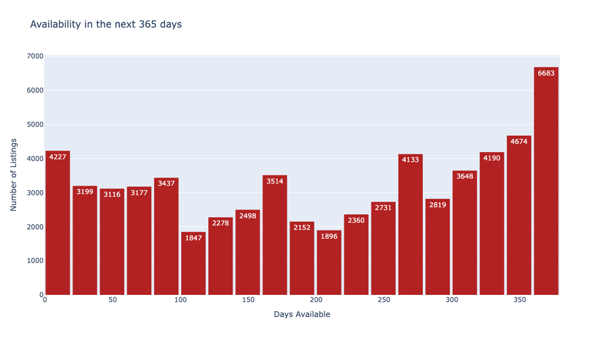

```python
fig = px.histogram(
    df_final,
    x='availability_365',
    nbins=30,
    title='Availability in the next 365 days',
    labels={'availability_365':'Days Available', 'Count':'Number of Listings'},
    color_discrete_sequence=['#B22222'],
    text_auto=True
)

fig.update_layout(
    width=1100,
    height=600,
    bargap=0.1,
    yaxis_title="Number of Listings"
)

fig.show()
```

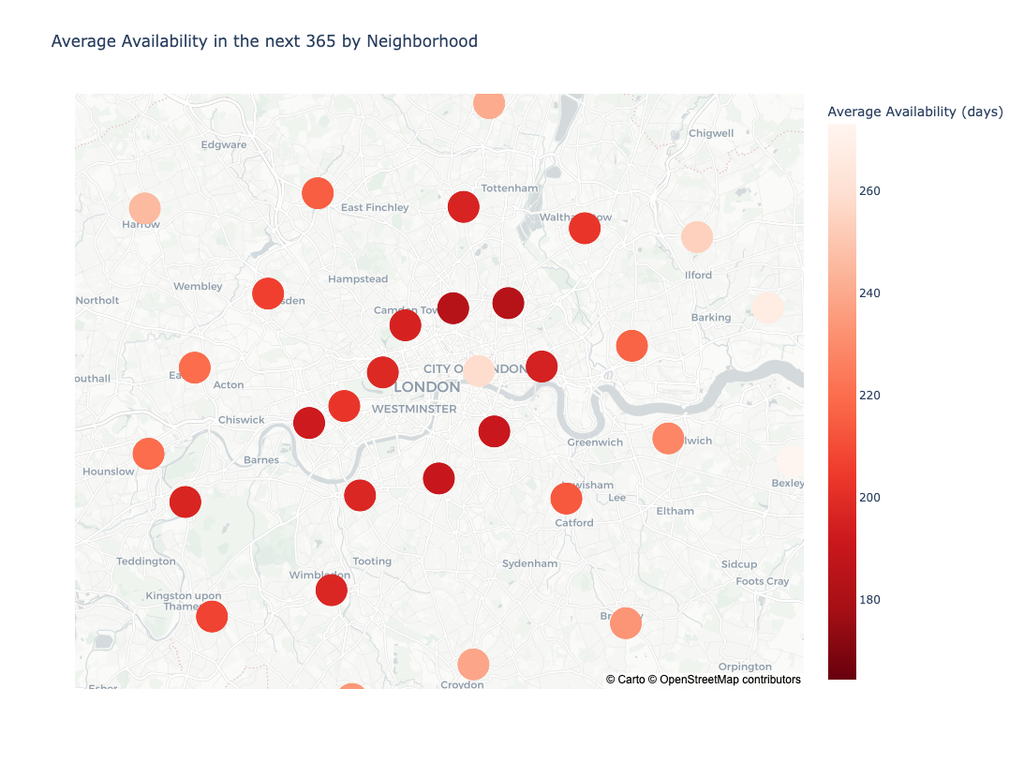

```python
df_map = df_final.groupby('neighbourhood_cleansed').agg({
    'availability_365':'mean',
    'latitude':'mean',
    'longitude':'mean'
}).reset_index()

fig = px.scatter_mapbox(
    df_map,
    lat='latitude',
    lon='longitude',
    size='availability_365',
    color='availability_365',
    hover_name='neighbourhood_cleansed',
    hover_data={'latitude':False, 'longitude':False},
    color_continuous_scale='Reds_r',
    size_max=30,
    zoom=10,
    title='Average Availability in the next 365 by Neighborhood',
    color_continuous_midpoint=df_map['availability_365'].mean(),
    labels={'availability_365': 'Average Availability (days)'}
)

fig.update_traces(marker=dict(size=35))

fig.update_layout(
    width=1100,
    height=800,
    mapbox_style="carto-positron")

fig.show()
```

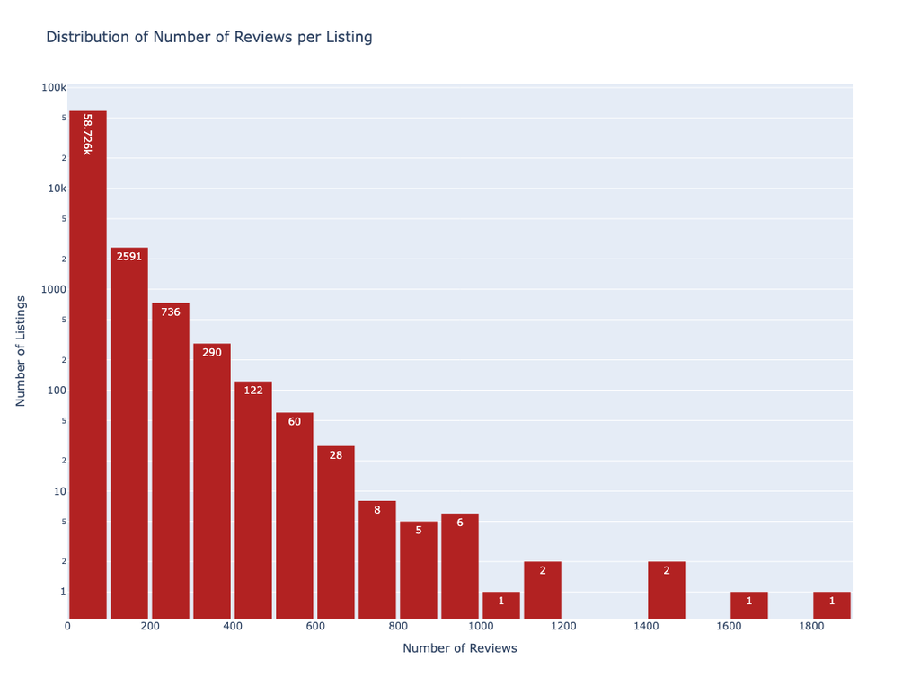

```python
fig = px.histogram(
    df_final,
    x='number_of_reviews',
    nbins=30,
    title='Distribution of Number of Reviews per Listing',
    labels={'number_of_reviews':'Number of Reviews', 'count':'Number of Listings'},
    color_discrete_sequence=['#B22222'],
    text_auto=True

)

fig.update_layout(
    width=1100,
    height=800,
    bargap=0.1,
    yaxis_type="log",
    yaxis_title="Number of Listings"
)

fig.show()
```

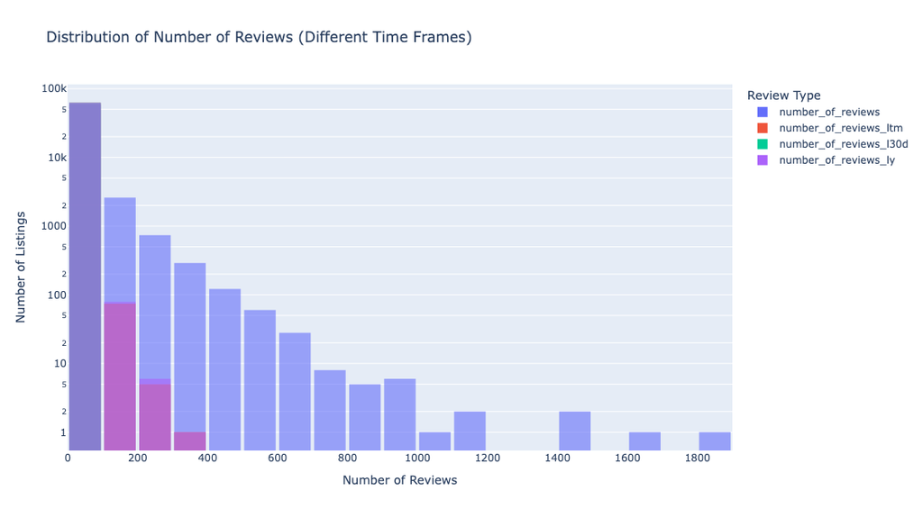

```python
fig = px.histogram(
    df_final,
    x=['number_of_reviews','number_of_reviews_ltm','number_of_reviews_l30d','number_of_reviews_ly'],
    nbins=30,
    title='Distribution of Number of Reviews (Different Time Frames)',
    labels={'value':'Number of Reviews', 'variable':'Review Type', 'count':'Number of Listings'},
    color='variable',
    barmode='overlay',
    opacity=0.6,
)

fig.update_layout(
    width=1100,
    height=600,
    yaxis_type="log",
    yaxis_title="Number of Listings",
    bargap=0.1)

fig.show()
```

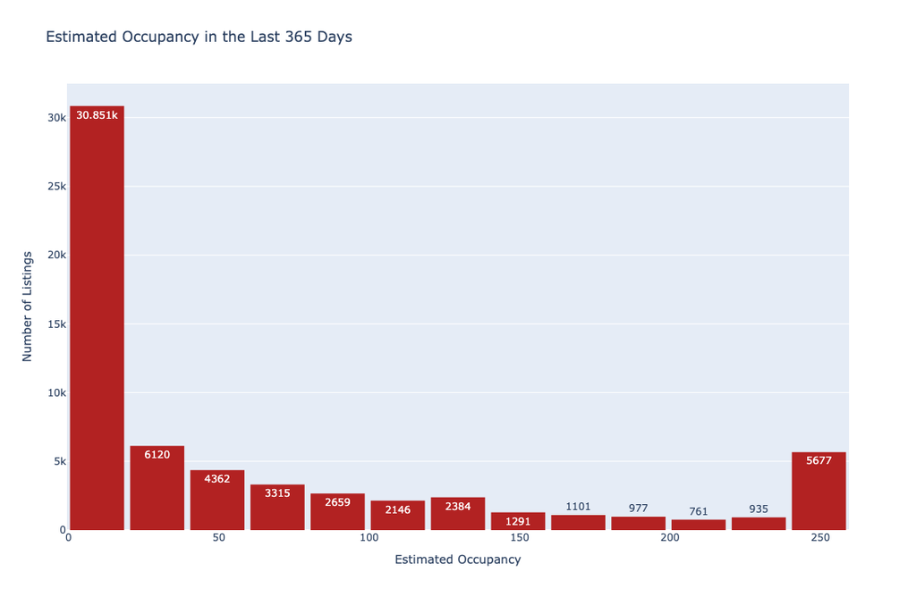

```python
fig = px.histogram(
    df_final,
    x='estimated_occupancy_l365d',
    nbins=15,
    title='Estimated Occupancy in the Last 365 Days',
    labels={'estimated_occupancy_l365d':'Estimated Occupancy', 'count':'Number of Listings'},
    color_discrete_sequence=['#B22222'],
    text_auto=True
)

fig.update_layout(
    width=1100,
    height=700,
    yaxis_title="Number of Listings",
    bargap=0.1)

fig.show()
```

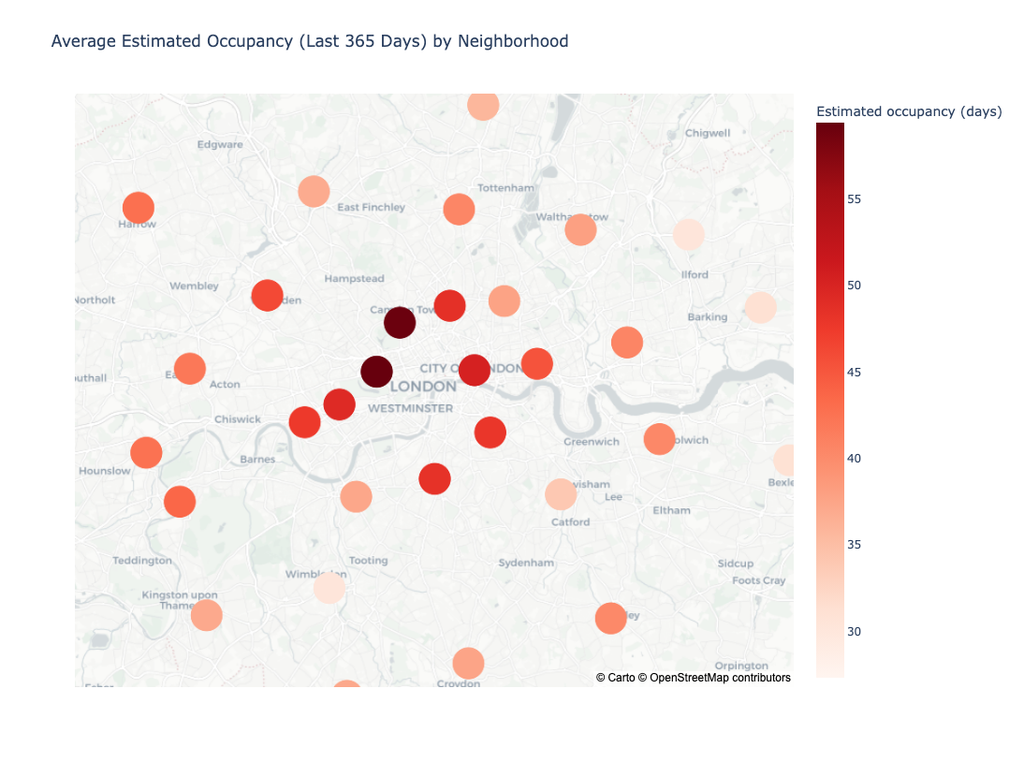

```python
# average occupancy per neighborhood
df_occ_map = df.groupby('neighbourhood_cleansed').agg({
    'estimated_occupancy_l365d':'mean',
    'latitude':'mean',
    'longitude':'mean'
}).reset_index()

fig = px.scatter_mapbox(
    df_occ_map,
    lat='latitude',
    lon='longitude',
    size='estimated_occupancy_l365d',
    color='estimated_occupancy_l365d',
    hover_name='neighbourhood_cleansed',
    hover_data={'latitude':False, 'longitude':False},
    color_continuous_scale='Reds',
    size_max=30,
    zoom=10,
    title='Average Estimated Occupancy (Last 365 Days) by Neighborhood'
)

fig.update_traces(marker=dict(size=35))

fig.update_layout(
    width=1100,
    height=800,
    coloraxis_colorbar=dict(title="Estimated occupancy (days)"),
    mapbox_style="carto-positron")

fig.show()
```

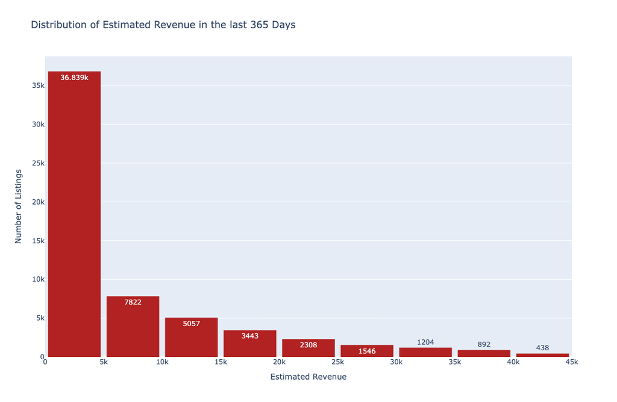

```python
df_revenue = df[df['estimated_revenue_l365d'] < df['estimated_revenue_l365d'].quantile(0.95)]

fig = px.histogram(
    df_revenue,
    x="estimated_revenue_l365d",
    nbins=20,
    title="Distribution of Estimated Revenue in the last 365 Days",
    labels={"estimated_revenue_l365d": "Estimated Revenue", "count":"Number of Listings"},
    color_discrete_sequence=["#B22222"],
    text_auto=True
)

fig.update_layout(
    width=1100,
    height=700,
    yaxis_title="Number of Listings",
    bargap=0.1
)

fig.show()
```

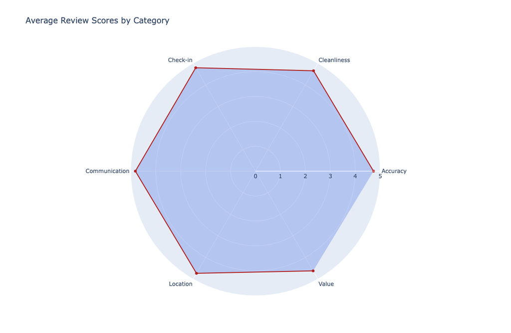

```python
import plotly.graph_objects as go

categories = ['Accuracy', 'Cleanliness', 'Check-in', 'Communication', 'Location', 'Value']
avg_scores = [
    df['review_scores_accuracy'].mean(),
    df['review_scores_cleanliness'].mean(),
    df['review_scores_checkin'].mean(),
    df['review_scores_communication'].mean(),
    df['review_scores_location'].mean(),
    df['review_scores_value'].mean()
]

fig = go.Figure()

fig.add_trace(go.Scatterpolar(
    r=avg_scores,
    theta=categories,
    fill='toself',
    name='Average Review Scores',
    line=dict(color='#B22222'),
    fillcolor='rgba(65,105,225,0.3)'
))

fig.update_layout(
    polar=dict(radialaxis=dict(visible=True, range=[0,5])),
    showlegend=False,
    width=1100,
    height=700,
    title="Average Review Scores by Category"
)

fig.show()
```